# Depixen Intern Case Study(Industrial Doors)

Metin Yüksel GÜNGÖR

10/26/2020

# 1 General Information

Industrial doors have many specific features that are arranged to give large-scale operations the transportation and movement protocols that they require, while also ensuring that the business maintains safe and secured at all times. All companies want ensure that they have the right door for their properties, whether a factory, warehouse or an office. Using well-made doors is a high priority for them.

Industrial doors come in a range of different shapes and sizes, covering every need in a commercial setting from security to temperature control. With so many different types to choose from, it can often be difficult to find the right solution for your business needs. There’s a variety of different options, and each has its own specific set of features and functions that make them an ideal solution for particular scenarios. If this all sounds a bit confusing, don’t worry – we’ve put together our top tips on some of the most common types of industrial doors so that you can find the right ones for your company’s requirements.

## 1.1 Roll Up Doors (Roller Shutters and Roller Grilles)

Roller shutters and roller grilles are both constructed from multiple panels to form a solid physical barrier when shut. Because of their construction, roller shutter doors are not only an affordable form of physical security, but they also take up very little space when the door is open. Although both roller shutters and roller grilles are often used by businesses for additional security, grilles are more likely to be used indoors, such as inside shopping centers, while roller shutters are usually an external solution, often found in large buildings and loading bays. Like most industrial door types, roll up doors can be manual or automatic for ease of use and added operational safety.

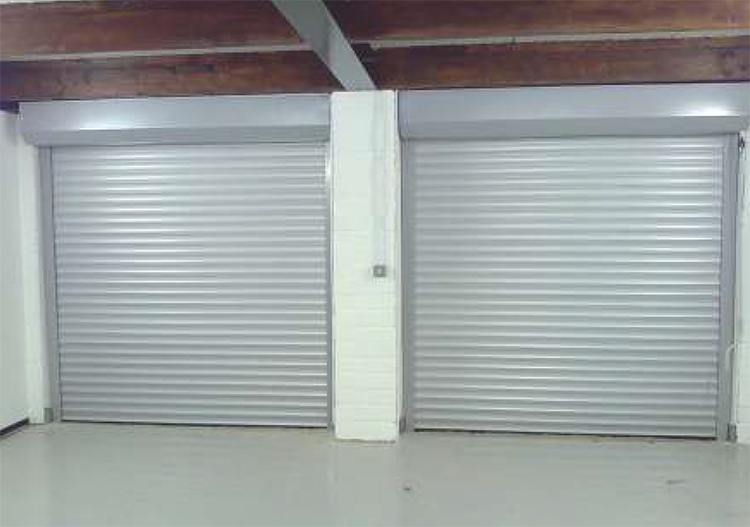

Roller Shutter

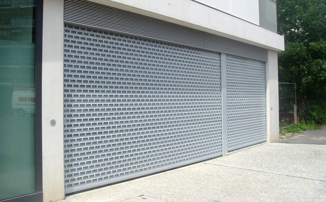

Roller Grill

## 1.2 High Speed Doors

High speed doors, as the name implies, are industrial doors which can be opened and closed at a much faster rate than other industrial door types. This type of industrial door is usually made up from steel sections with some manufacturers adding in thermal breaks and PU foam for added insulation. Aside from their fast operation and insulation properties, high-speed doors are also popular due to their sturdy construction which makes them a long-lasting choice.

Because of their fast operation, high-speed doors are most commonly used in cold storage facilities as they can minimize the temperature changes that occur when accessing temperature-controlled environments.

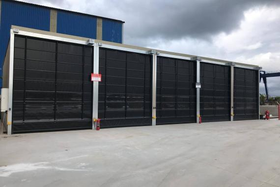

## 1.3 Sectional Doors

Sectional doors have multiple benefits that making them ideal for industrial usage whether you are looking for added security, a door solution that will offer a large opening space, or you are concerned about insulation.

Like roller shutters, sectional doors are made up from multiple panels, which allows the door to has a vertical actuation that takes up minimal space, making sectional doors the perfect space-saving option for industrial environments. Since they are most commonly made from aluminium and steel, sectional doors are not only lightweight but will withstand heavy use with frequent daily operation.

[figure not shown]

## 1.4 Strip Curtains

Far cheaper than other industrial door types, PVC strip curtains offer an economical way of separating production areas while providing some protection against heat loss and protecting products and staff.

Because they can withstand extremely cold temperatures before the PVC material breaks, strip curtains are also widely used in cold storage areas and commercial freezers.

Also transparent type PVC strip curtains provide high visibility security especially in places where vehicle and personnel entrance and exit are dense.

[figure not shown]

## 1.5 Fire Doors

While fire doors aren’t strictly limited to the commercial door market, they are one of the most popular types of industrial doors due to their specialized function. Sliding fire doors, in particular, are often used in areas that are used by both vehicles and pedestrians in order to provide a quick exit in case of an emergency.

[figure not shown]

# 2 Quality Standarts

Quality control (QC) is a process by which entities review the quality of all factors involved in production. This case is valid for industrial doors, too. Industrial door production is based on widely varying international standards and regulations. The standards and regulations guarantee the product properties that exclude risk factors. Furthermore, the various classifications within these standards provide a criterion for determining which requirements your door should meet. Most of industrial door manufacturers are tested by independent and accredited institutions based on these international standards and regulations. Once the properties have been demonstrated, the door models receive their certificates and classifications pursuant to the standard.

Examples of the independent and accredited institutions include Peutz, Efectis Nederland, TNO, SKG and Warrington. All test methods are laid down in the standard and these are strictly observed. This makes certification the best and guaranteed proof of quality.

In industrial doors sector, EN Standards (European Standards) is the most preferable international standards at certification. European Standards are technical standards drafted and maintained by European Committee for Standardization. These standards are an expression of requirements for products, processes or services to meet the requirement of suitability for a particular purpose.

[figure not shown]

Currently, EN qualified technical recommendations are not obligatory and their use is voluntary. But, in this area, an industrial door without EN certification may cause serious malfunctions in short term. Therefore, it is very important to control EN certifications in buying industrial door.

There is a suite of European standards that makes it easier to specify industrial doors. These are;

## 2.1 Wind Load Performance: EN 12424

Wind Load Performance: EN 12424 identifies five classes of wind load resistance from 0 to 4. The higher the class number the greater the wind loads a door can resist.

The valid standard for the information relating to wind loads in power-operated doors is EN 12424. This standard defines the classification of the wind loads for doors when closed. To this end, the wind load is understood as the differential pressure from one side of the completely closed door to the other side. There is no information relating to the running performance for a door under wind load.

Disregarding various general conditions, such as installation situation and geographic influences, for example, the following table can be used for the approximate conversion of wind speeds.

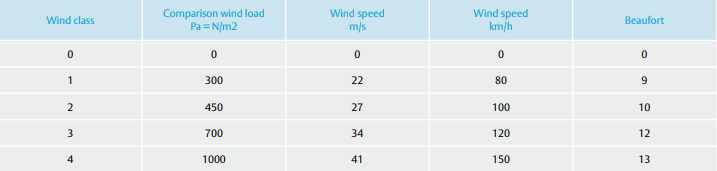

## 2.2 Water Resistance: EN 12425

Water Resistance: EN 12425 specifies four classes of resistance to water penetration. Typically industrial doors which is no performance determined are Class 0, which is tested with 15-minute water spray at 30 Pa are Class 1, which is tested to resist a 20-minute water spray at 50 Pa are Class 2, and which has a special subject of contract approval between the manufacturer and the customer are Class 3.

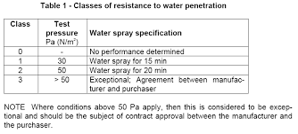

## 2.3 Air Permeability: EN 12426

Air Permeability: EN 12426 classifies the air permeability of doors. The seven classes run from 0 – 6. The higher the class, the lower permeability. A Class 1 door has a permeability of 24m˛/m˙h at 50 Pa. Each class as a permeability rate half that of the previous Class.

## 2.4 Safety: EN 12453

Safety: EN 12453 defines safety requirements for power-operated doors. Hazards and risks are identified such as crushing hazard between the door leaves and perimeter of opening. Safeguards, design strategies and criteria for avoiding hazards are listed.

## 2.5 Mechanical Requirements and Operational Durability: EN 12604

Mechanical Requirements and Operational Durability: EN 12604 specifies the mechanical requirements for industrial doors, such as strength and the factor of safety. This standard is important in assessing potential durability, as it requires manufacturers to state the number of cycles doors have been tested to. Durability is judged by reference to the economic life of the door. In other words, when the costs of maintaining the door are greater than the cost of door replacement.

## 2.6 Installation and Use: EN 12635

Installation and Use: EN 12635 covers installation and use of industrial doors. This includes the identification of maintenance and repair activities which are essential for life cycle management and planning.

## 2.7 Thermal Transmittance: EN 12428

Thermal Transmittance: EN 12428 specifies the calculation requirements for the thermal transmittance for doors in a closed position. This calculation can include different types of glazing, frames which with or without thermal breaks, different types of opaque panels, the frame area, and the panel area.

# 3 Activation of Packages

```r
library(dplyr)
```

```r
library(ggplot2)
library(lubridate)
library(tidyverse)
library(tidyr)
library(kableExtra)
library(openxlsx)
library(readxl)
library(RColorBrewer)
library(wordcloud)
library(corrplot)
library(rpart)
library(rpart.plot)
library(caret)
```

# 4 Data Import

```r
getwd()
```

```
## [1] "C:/Users/Metin/Documents/GitHub/so-so"
```

```r
setwd("C:/Users/Metin/Desktop/R Depixen")
Data  <- read.xlsx("Data.xlsx")
```

# 5 Explanatory Analysis of Data

## 5.1 Existing Brands

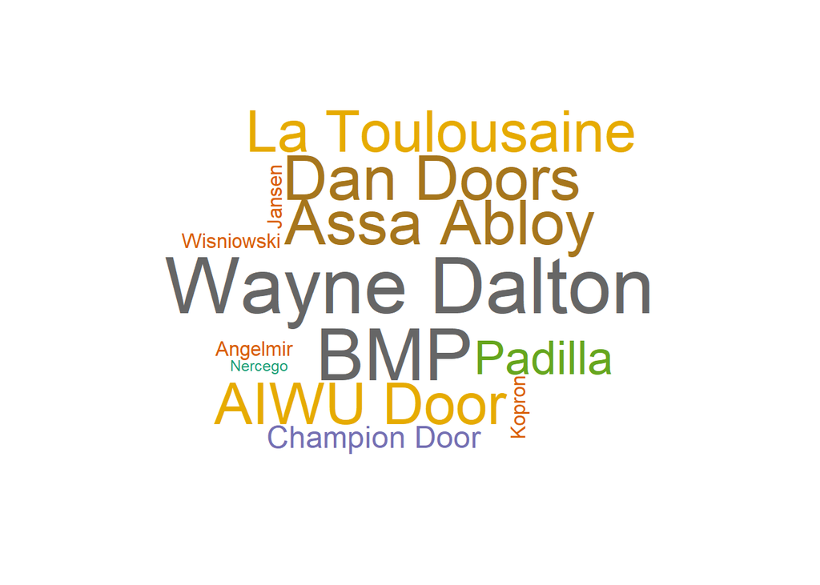

```r
word <- Data %>%
  group_by(Brand) %>%
  summarise(TotalNumber = n())

set.seed(5)
wordcloud(words = word$Brand, freq = word$TotalNumber, min.freq = 1,
          max.words=500, random.order=FALSE, rot.per=0.15,
          colors=brewer.pal(8, "Dark2"))
```

## 5.2 According to Door Types

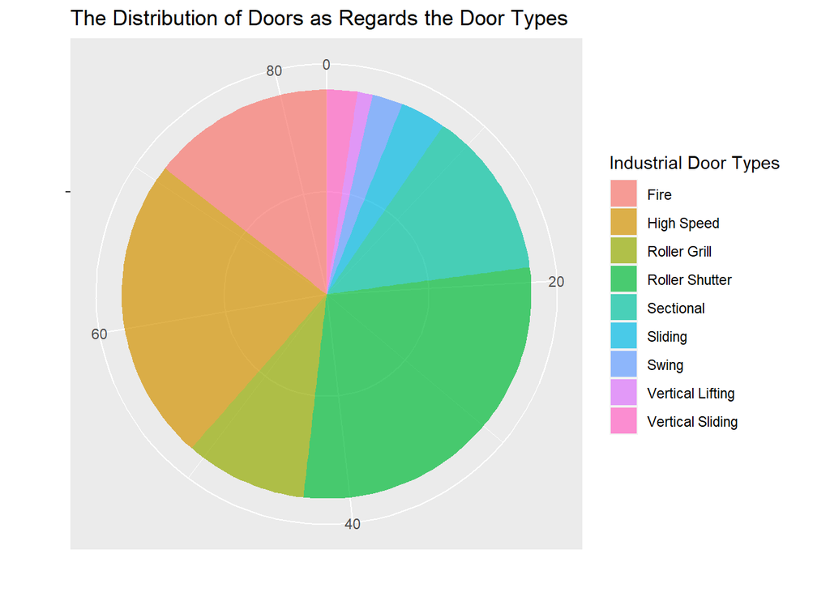

```r
Data %>%
  group_by(Type) %>%
  summarise(Totalnumber = n()) %>%
  ggplot(., aes(x = '', y = Totalnumber, fill = Type)) +
    geom_bar(stat = "identity", width = 1, alpha = 0.7) +
    coord_polar("y")+
   labs(title = "The Distribution of Doors as Regards the Door Types",
        x = "",
        y = "",
        fill = "Industrial Door Types")
```

There are 9 types of industrial doors. These are; Fire, High Speed, Roller Grill, Roller Shutter, Sectional, Sliding, Swing, Vertical Lifting, and Vertical Sliding. The pie chart shows us the distribution of each industrial door type in the data.

### 5.2.1 Thicknesses

```r
Data %>%
  group_by(Type) %>%
  summarise(TotalNumber = n(),
            MinThickness_mm = min(`Thickness(mm)`),
            MeanThickness_mm = mean(`Thickness(mm)`),
            MaxThickness_mm = max(`Thickness(mm)`))
```

```
## # A tibble: 9 x 5
##   Type             TotalNumber MinThickness_mm MeanThickness_mm MaxThickness_mm
##   <chr>                  <int>           <dbl>            <dbl>           <dbl>
## 1 Fire                      12            53               65.2             100
## 2 High Speed                20             1.5            121.              290
## 3 Roller Grill               8            10               18                26
## 4 Roller Shutter            24            22               58.2             120
## 5 Sectional                 11            40               49.5              82
## 6 Sliding                    3            75               76.7              80
## 7 Swing                      2            70               72.5              75
## 8 Vertical Lifting           1           100              100               100
## 9 Vertical Sliding           2           100              100               100
```

When we look at the above table, we can see that the minimum, average, maximum thickness values, and also the total numbers for every door type. Generally, the thickest doors are high speed types. Roller Grilles have less thickness than the other types.

### 5.2.2 Max Width - Max Height Relations

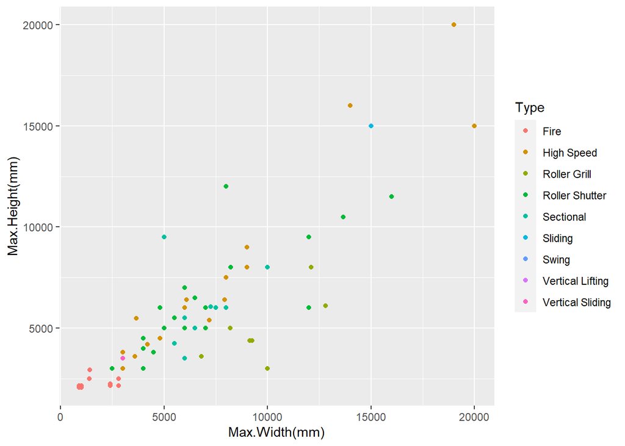

```r
ggplot(Data, aes(`Max.Width(mm)`, `Max.Height(mm)`, color = Type)) +
  geom_point()
```

In this plot, each door model is corresponded to a point. And, every point indicates a door model’s maximum width and height values. Also, door types were categorized as regards the colors.

### 5.2.3 Thermal Transmittance

[figure not shown]

```r
Data %>%
  group_by(Type) %>%
  summarise(Typenumber = n(),
            Average = mean(`Thermal.Transmittance(.W/m2K)`)) %>%
  ggplot(.,aes(x = Type, y = Typenumber)) +
  geom_point(size=5) +
    geom_segment(aes(x=Type,
                     xend=Type,
                     y=0,
                     yend=Typenumber))+
  labs(title = "The Average Thermal Transmittance Values for each Door Type",
       x = "Door Type",
       y = "Average Thermal Transmittance Value(w/m²K)")
```

### 5.2.4 Opening Speed - Closing Speed Relations

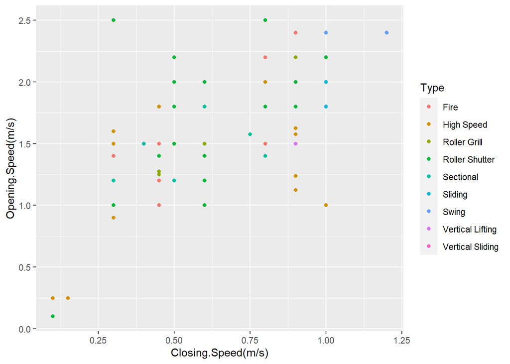

```r
ggplot(Data, aes(`Closing.Speed(m/s)`, `Opening.Speed(m/s)`, color = Type)) +
  geom_point()
```

In the above plot, each point represents a door model. These door models were located according to closing speed(m/s) and opening speed(m/s). Additionally, each door type was matched with a color.

## 5.3 According to Door Materials

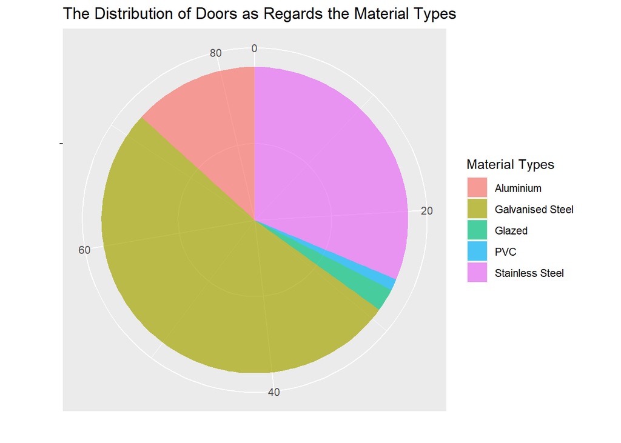

```r
Data %>%
  group_by(Material) %>%
  summarise(Totalnumber = n()) %>%
  ggplot(., aes(x = '', y = Totalnumber, fill = Material)) +
    geom_bar(stat = "identity", width = 1, alpha = 0.7) +
    coord_polar("y")+
   labs(title = "The Distribution of Doors as Regards the Material Types",
        x = "",
        y = "",
        fill = "Material Types")
```

This pie chart indicates us that the distrubition of doors according to material types. These are; aluminum, galvanised steel, glazed, PVC, and stainless steel. The data has the most galvanised steel door type.

### 5.3.1 Thicknesses

```r
Data %>%
  group_by(Material) %>%
  summarise(TotalNumber = n(),
            MinThickness_mm = min(`Thickness(mm)`),
            MeanThickness_mm = mean(`Thickness(mm)`),
            MaxThickness_mm = max(`Thickness(mm)`))
```

```
## # A tibble: 5 x 5
##   Material         TotalNumber MinThickness_mm MeanThickness_mm MaxThickness_mm
##   <chr>                  <int>           <dbl>            <dbl>           <dbl>
## 1 Aluminium                 11            26               98.5           290
## 2 Galvanised Steel          43            10               68             160
## 3 Glazed                     2            44               52              60
## 4 PVC                        1             1.5              1.5             1.5
## 5 Stainless Steel           26            18               70.9           150
```

The above table shows the total number, minimum thickness, average thickness, and maximum thickness values for every material type. Thickness values are millimetric.

### 5.3.2 Max Width - Max Height Relations

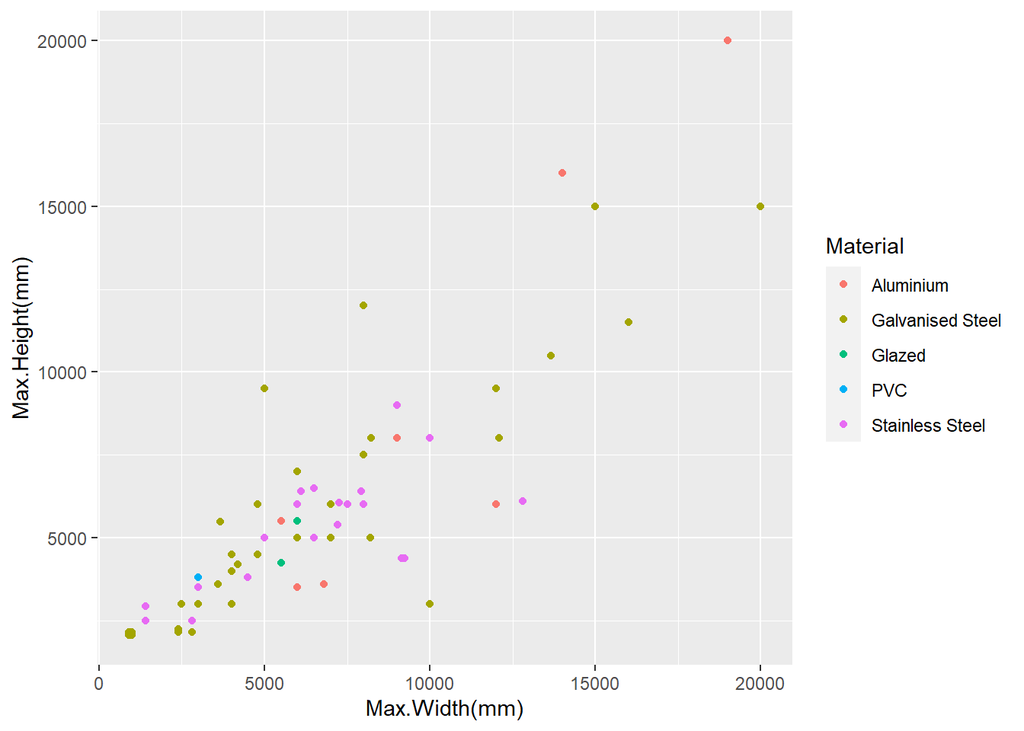

```r
ggplot(Data, aes(`Max.Width(mm)`, `Max.Height(mm)`, color = Material)) +
  geom_point()
```

When we look at the above plot, we can see that every door model is located at a point which is according to maximum width, and maximum height values. Also, these points were colored as regards material types.

### 5.3.3 Thermal Transmittance

[figure not shown]

```r
Data %>%
  group_by(Material) %>%
  summarise(Materialnumber = n(),
            Average = mean(`Thermal.Transmittance(.W/m2K)`)) %>%
  ggplot(.,aes(x = Material, y = Materialnumber)) +
  geom_point(size=5) +
    geom_segment(aes(x=Material,
                     xend=Material,
                     y=0,
                     yend=Materialnumber))+
  labs(title = "The Average Thermal Transmittance Values for each Door Material Type",
       x = "Door Material Type",
       y = "Average Thermal Transmittance Value(w/m²K)")
```

### 5.3.4 Opening Speed - Closing Speed Relations

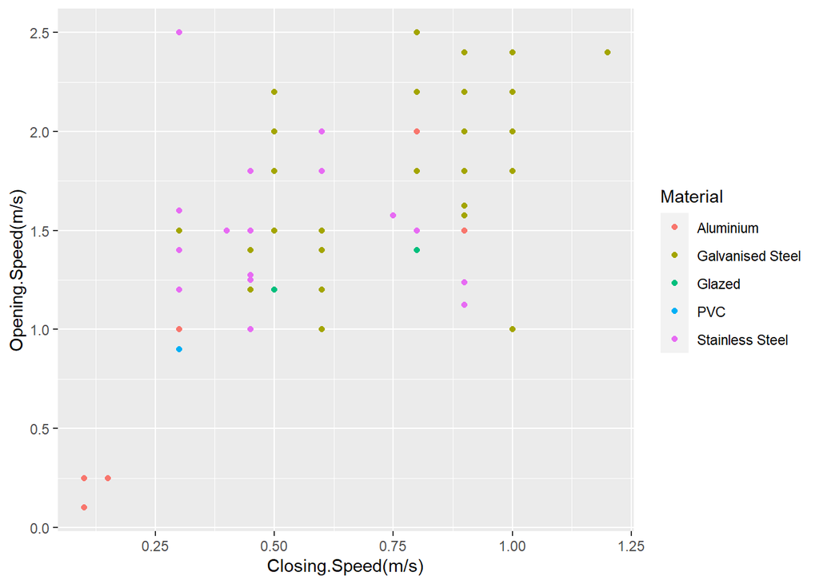

```r
ggplot(Data, aes(`Closing.Speed(m/s)`, `Opening.Speed(m/s)`, color = Material)) +
  geom_point()
```

From this chart, we can get information about the opening, and closing speed values for all door models. Moreover, these door models were categorized according to material types.

## 5.4 Correlations

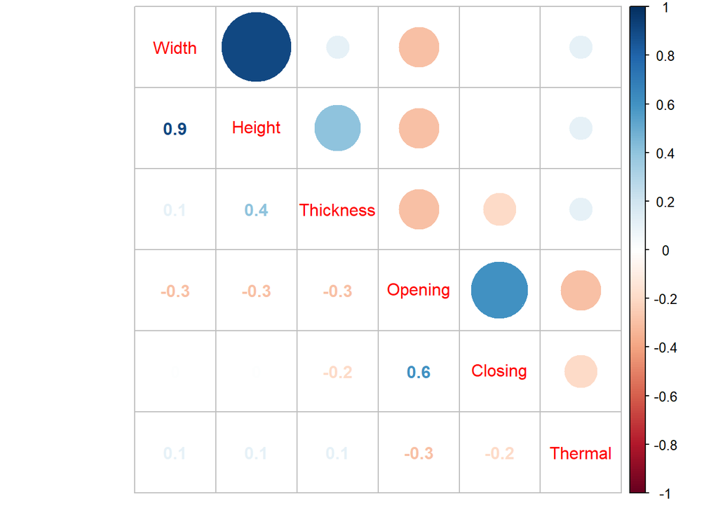

```r
data_numerical <- Data %>% select(`Max.Width(mm)`, `Max.Height(mm)`, `Thickness(mm)`, `Opening.Speed(m/s)`, `Closing.Speed(m/s)`, `Thermal.Transmittance(.W/m2K)`)

data_numerical1 <- rename(data_numerical, Width = `Max.Width(mm)`, Height = `Max.Height(mm)`, Thickness = `Thickness(mm)`, Opening = `Opening.Speed(m/s)`, Closing = `Closing.Speed(m/s)`, Thermal = `Thermal.Transmittance(.W/m2K)`)

data_correlation <- round(cor(data_numerical1), 1)

corrplot.mixed(data_correlation)
```

This correlation matrix is formed to indicate the strength of the relationships among all numerical variables. According to this matrix, width and height have a significantly positive relationship(+0.9). Also, height - thickness and opening - closing variables have good positive relationships. On the other hand, in the matrix, lots of weak negative relationships are seen around -0.3.

# 6 References

[HAG The Door Specialists](https://www.hag.co.uk/guide-to-industrial-doors/)

[Entrepreneur Handbook](https://entrepreneurhandbook.co.uk/different-types-of-industrial-door/)

[Market Business News](https://marketbusinessnews.com/a-guide-to-different-types-of-industrial-doors-and-their-uses/199693/)

[Hormann Company](https://www.hormann.co.uk/industry-commerce-and-public-authorities/industrial-doors/)

[Medium Blog](https://medium.com/@searsallena)

Archi Expo

[Protec Advanced Special Door Engineering](https://protecindustrialdoors.com/protec-industrial-doors/standards-regulations/)

[European Standards](https://www.en-standard.eu/)

[Wikipedia - List of EN Standards](https://en.wikipedia.org/wiki/List_of_EN_standards)

[Wikipedia - European Committee for Standardization](https://en.wikipedia.org/wiki/European_Committee_for_Standardization)

[Greenspec Blog](https://www.greenspec.co.uk/building-design/industrial-doors/)

[Assa Abloy Entrance Systems](https://www.assaabloyentrance.nl/AAES/PRODUCTS_2.1/PRODUCT-DOCUMENTATION/NL/high-performance-doors/food-processing-doors/doc/1.Productbrochures/EN_AAES_HPDS_Resistance_to_wind_load.pdf)